# Project1

Meriam Berka

2023-09-15

# setup

## Part 1

#1. Histogram of ratings

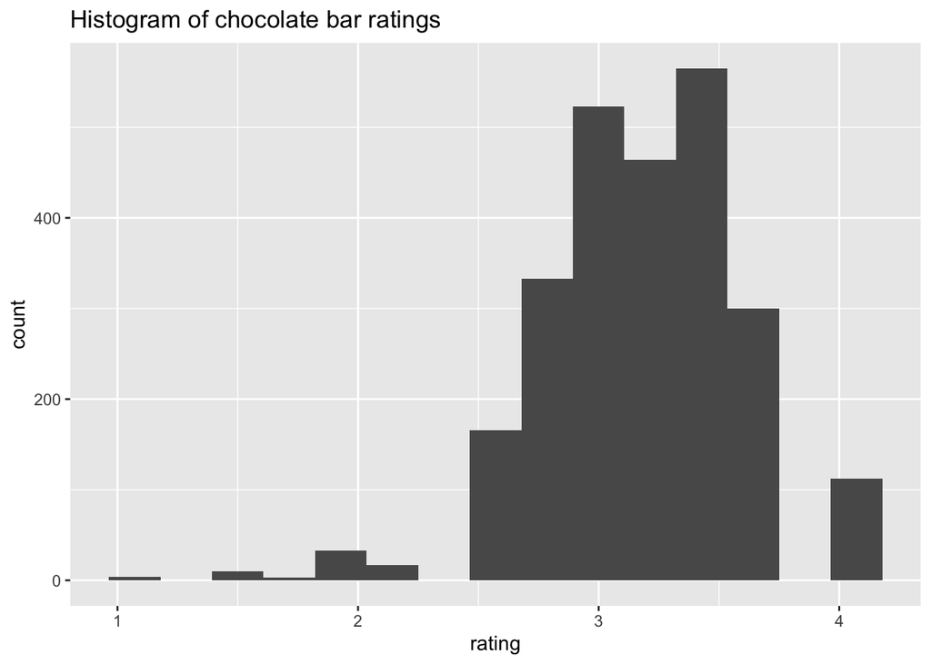

```r
library(tidyverse)
library(here)
chocolate <- readRDS(here("data", "chocolate.RDS"))
ggplot(chocolate, aes(x=rating)) + geom_histogram(bins=15) + ggtitle("Histogram of chocolate bar ratings")
```

Increasing the number of bins allows more granularity of data, better showing the shape of the distribution. However, if we increase the number of bins too much we start to have gaps in our data because the number of bins exceeds the number of potential scores. I selected a 15 bin histogram because it nicely shows the shape of the distribution but doesn’t have the gapping a 20+ bin histogram does.

#2. Number of ratings by country of bean origin

```r
library(dplyr)
chocolate <- readRDS(here("data", "chocolate.RDS"))

count <-count(chocolate, country_of_bean_origin, wt=NULL, sort=TRUE)
print(count, n=62)
```

```
## # A tibble: 62 × 2
##    country_of_bean_origin     n
##    <chr>                  <int>
##  1 Venezuela                253
##  2 Peru                     244
##  3 Dominican Republic       226
##  4 Ecuador                  219
##  5 Madagascar               177
##  6 Blend                    156
##  7 Nicaragua                100
##  8 Bolivia                   80
##  9 Colombia                  79
## 10 Tanzania                  79
## 11 Brazil                    78
## 12 Belize                    76
```

[output cut: 50 more lines]

The number of ratings by each country of origin is described in the table above

#3. Average ratings for Ecuadorian beans

```r
library(dplyr)
library(knitr)
chocolate <- readRDS(here("data", "chocolate.RDS"))

ecud <- filter(chocolate,country_of_bean_origin == "Ecuador")
ecud <- mutate(ecud, mean=mean(rating, na.rm = TRUE))
ecud <- mutate(ecud, sd=sd(rating, na.rm = TRUE))
ecud <- mutate(ecud, present=case_when(!is.na(rating) ~ 1 , is.na(rating) ~ 0 ))
ecud <- mutate(ecud, total=sum(present))
ecud <- select(ecud, (mean:total))
ecud <- select(ecud, -(present))
ecud <- filter(ecud, !row_number()!= 1 )
knitr::kable(head(ecud[, 1:3]), "pipe")
```

| mean | sd | total |
| --- | --- | --- |
| 3.164384 | 0.5122678 | 219 |

Average ratings, standard deviation of ratings and total number of ratings for Ecuadorian chocolates

#4.Best manufacturer

```r
library(dplyr)
chocolate <- readRDS(here("data", "chocolate.RDS"))

ecud <- filter(chocolate,country_of_bean_origin == "Ecuador")
ecud <- mutate(ecud, mean=mean(rating, na.rm = TRUE))
ecud <- mutate(ecud, sd=sd(rating, na.rm = TRUE))
ecud <- mutate(ecud, present=case_when(!is.na(rating) ~ 1 , is.na(rating) ~ 0 ))
ecud <- mutate(ecud, total=sum(present))
company <- group_by(ecud, company_manufacturer)
summarize(company, rating=mean(rating, na.rm = TRUE))
```

```
## # A tibble: 136 × 2
##    company_manufacturer  rating
##    <chr>                  <dbl>
##  1 A. Morin                3.75
##  2 Aequare (Gianduja)      2.88
##  3 Alexandre               3.5
##  4 Altus aka Cao Artisan   2.75
##  5 Amano                   4
##  6 Amatller (Simon Coll)   2.75
##  7 Amedei                  3
##  8 Ara                     2.75
##  9 Arete                   3.44
## 10 Askinosie               3
## # ℹ 126 more rows
```

#5.Average rating by country of origin

```r
chocolate <- readRDS(here("data", "chocolate.RDS"))

country <- group_by(chocolate, country_of_bean_origin)
country <- summarize(country, rating=mean(rating, na.rm = TRUE))
country <- arrange(country, desc(rating))
knitr::kable(head(country[, 1:2]), "pipe")
```

| country_of_bean_origin | rating |
| --- | --- |
| Tobago | 3.625000 |
| China | 3.500000 |
| Sao Tome & Principe | 3.500000 |
| Solomon Islands | 3.450000 |
| Congo | 3.318182 |
| Thailand | 3.300000 |

Tobago (3.63), China (3.50), and Sao Tome & Principe (3.50) are the countries of origin that have the highest average ratings.

#6.Average rating by country of origin in countries with 10+ ratings

```r
library(dplyr)
chocolate <- readRDS(here("data", "chocolate.RDS"))

country <- group_by(chocolate, country_of_bean_origin)
country_n <- mutate(country, n=n())
country_n <- filter(country_n, n>=10)
country_n <- summarize(country_n, rating=mean(rating, na.rm = TRUE))
country_n <- arrange(country_n, desc(rating))
knitr::kable(head(country_n[, 1:2]), "pipe")
```

| country_of_bean_origin | rating |
| --- | --- |
| Solomon Islands | 3.450000 |
| Congo | 3.318182 |
| Cuba | 3.291667 |
| Vietnam | 3.287671 |
| Papua New Guinea | 3.280000 |
| Madagascar | 3.266949 |

Solomon Islands (3.45), Congo (3.32), and Cuba (3.29) are the countries of origin that have the highest average rating after filtering out countries with fewer than 10 chococlate bar reviews.

#7.

```r
library(dplyr)
library(forcats)
chocolate <- readRDS(here("data", "chocolate.RDS"))

country <- group_by(chocolate, country_of_bean_origin)
country <- mutate(country, n=n())
country <- filter(country, n>=50)
country <- mutate(country, c_percent = str_remove(cocoa_percent, "%"))
country$c_percent <-as.numeric(country$c_percent)
country <- mutate(country, percent = case_when(c_percent < 60 ~ "1", c_percent >= 60 & c_percent < 70 ~ "2", c_percent >= 70 & c_percent < 90 ~ "3", c_percent >= 90 ~ "4"))

country <- country %>% mutate(percent = fct_relevel(percent, c("2", "3", "4"), after=1))
#Belize
Belize <- filter(country, country_of_bean_origin=="Belize")
qplot(percent, rating, data=Belize, geom="boxplot") + ggtitle("Belize")
```

[output not shown]

```r
#Blend
Blend <- filter(country, country_of_bean_origin=="Blend")
qplot(percent, rating, data=Blend, geom="boxplot") + ggtitle("Blend")
```

[output not shown]

```r
#Bolivia
Bolivia <- filter(country, country_of_bean_origin=="Bolivia")
qplot(percent, rating, data=Bolivia, geom="boxplot") + ggtitle("Bolivia")
```

[output not shown]

```r
#Brazil
Brazil <- filter(country, country_of_bean_origin=="Brazil")
qplot(percent, rating, data=Brazil, geom="boxplot") + ggtitle("Brazil")
```

[output not shown]

```r
#Colombia
Colombia <- filter(country, country_of_bean_origin=="Colombia")
qplot(percent, rating, data=Colombia, geom="boxplot") + ggtitle("Colombia")
```

[output not shown]

```r
#Dominican Republic
DR <- filter(country, country_of_bean_origin=="Dominican Republic")
qplot(percent, rating, data=DR, geom="boxplot") + ggtitle("Dominican Republic")
```

[output not shown]

```r
#Ecuador
Ecuador <- filter(country, country_of_bean_origin=="Ecuador")
qplot(percent, rating, data=Ecuador, geom="boxplot") + ggtitle("Ecuador")
```

[output not shown]

```r
#Guatemala
Guatemala <- filter(country, country_of_bean_origin=="Guatemala")
qplot(percent, rating, data=Guatemala, geom="boxplot") + ggtitle("Guatemala")
```

[output not shown]

```r
#Madagascar
Madagascar <- filter(country, country_of_bean_origin=="Madagascar")
qplot(percent, rating, data=Madagascar, geom="boxplot") + ggtitle("Madagascar")
```

[output not shown]

```r
#Mexico
Mexico <- filter(country, country_of_bean_origin=="Mexico")
qplot(percent, rating, data=Mexico, geom="boxplot") + ggtitle("Mexico")
```

[output not shown]

```r
#Nicaragua
Nicaragua <- filter(country, country_of_bean_origin=="Nicaragua")
qplot(percent, rating, data=Nicaragua, geom="boxplot") + ggtitle("Nicaragua")
```

[output not shown]

```r
#Papua New Guinea
PNG <- filter(country, country_of_bean_origin=="Papua New Guinea")
qplot(percent, rating, data=PNG, geom="boxplot") + ggtitle("Papua New Guinea")
```

[output not shown]

```r
#Peru
Peru <- filter(country, country_of_bean_origin=="Peru")
qplot(percent, rating, data=Peru, geom="boxplot") + ggtitle("Peru")
```

[output not shown]

```r
#Tanzania
Tanzania <- filter(country, country_of_bean_origin=="Tanzania")
qplot(percent, rating, data=Tanzania, geom="boxplot") + ggtitle("Tanzania")
```

[output not shown]

```r
#Venezuela
Venezuela <- filter(country, country_of_bean_origin=="Venezuela")
qplot(percent, rating, data=Venezuela, geom="boxplot") + ggtitle("Venezuela")
```

[output not shown]